# Replicación del Paper

Onna Nayyu Leyva Alcantara

2023-03-21

# Día 1

Descargar el html con el ejercicio:

```bash
scp oleyva@dna.lavis.unam.mx:/mnt/Timina/bioinfoII/drobles/variant_calling/Variant_calling_exercises.html /home/onna/Documentos/clases4s/daniela/ejer1
```

During this week, we will replicate the findings of the original paper by performing variant calling and quality filtering, and using Ensembl VEP to predict variant consequences.

These exercises are based on the ones offered in the Wellcome Trust Advanced Courses and Scientific Conferences ‘NGS Sequencing Bioinformatics’. Some of the text is taken from other exercises written by Jackie and Thomas Keane.

Please write a RMarkdown document with your answers to these exercises and send it to drobles@liigh.unam.mx when you have finished it, preferably in HTML format.

Paper:

Kok et al. (2012): Laboratory evolution of new lactate transporter genes in a jen1D mutant of Saccharomyces cerevisiae and their identification as ADY2 alleles by whole-genome resequencing and transcriptome analysis. FEMS Yeast Res, 12:359-74.

Wild-type laboratory strains of Saccharomyces cerevisiae, like the reference strain S288C or the widely used strain CEN.PK113-7D can grow on a variety of carbon sources including lactate.

In a recent publication1, a knock-out mutant strain based on CEN.PK113-7D was generated, in which the gene for the only known lactate transporter in yeast, jen1, is disrupted by an inserted reporter cassete. As expected, this strain cannot use lactate as a carbon source. Laboratory evolution was used then on this strain to obtain two substrains that had regained the ability to grow on lactate. Both substrains, IMW004 and IMW005, were subjected to WGS to gain insight into the genomic changes that these strains had undergone compared to CEN.PK113-7D over ~100 generations of laboratory evolution and that might explain their ability to grow on lactate despite the disruption of the jen1 gene.

Strikingly, the substrains harbored independent point mutations in the acetate transporter gene ADY2 and subsequent experiments showed that these mutations are likely to cause changes in the substrate specificity of this transporter.

Go to /mnt/Timina/bioinfoII/drobles/variant_calling/data/. There, you will find:

- The S288C reference sequence in FASTA format (S288C_ref.fa) and its index (S288C_ref.fa.fai)
- a BAM file of NGS reads from the CEN.PK113-7D parent strain (reads are a random subset of those available through the NCBI SRA under accession number SRX129922) (SRR445715.aligned.sorted.bam) and its index (SRR445715.aligned.sorted.bam.bai)
- a BAM file of NGS reads from the lab-evolved substrain IMW004 (same reads as available under the NCBI SRA accession number SRX129995), (SRR445716.aligned.sorted.bam) and its index (SRR445716.aligned.sorted.bam.bai)
- a BAM file of NGS reads from the lab-evolved substrain IMW005 (same reads as available under the NCBI accession number SRX129996) (SRR445717.aligned.sorted.bam) and its index (SRR445717.aligned.sorted.bam.bai)
- Other files related to the work in this module (you can check the readme inside this directory if you’re curious)

## 1. Understanding our data

Before we perform variant calling, it is important to check the data that we will be working with. First, you will need to load the samtools module:

```bash
# module load samtools/1.10
module load samtools
```

Go into your working directory and create a special folder for this exercise. Go into this new folder (ejer1). Now get some statistics for these three BAM files:

```bash
samtools stats -r /mnt/Timina/bioinfoII/drobles/variant_calling/data/S288C_ref.fa /mnt/Timina/bioinfoII/drobles/variant_calling/data/SRR445715.aligned.sorted.bam > SRR445715.stats
samtools stats -r /mnt/Timina/bioinfoII/drobles/variant_calling/data/S288C_ref.fa /mnt/Timina/bioinfoII/drobles/variant_calling/data/SRR445716.aligned.sorted.bam > SRR445716.stats
samtools stats -r /mnt/Timina/bioinfoII/drobles/variant_calling/data/S288C_ref.fa /mnt/Timina/bioinfoII/drobles/variant_calling/data/SRR445717.aligned.sorted.bam > SRR445717.stats
plot-bamstats -r /mnt/Timina/bioinfoII/drobles/variant_calling/data/other_files/S288C_ref.fa.gc -p SRR445715.graphs/ SRR445715.stats
plot-bamstats -r /mnt/Timina/bioinfoII/drobles/variant_calling/data/other_files/S288C_ref.fa.gc -p SRR445716.graphs/ SRR445716.stats
plot-bamstats -r /mnt/Timina/bioinfoII/drobles/variant_calling/data/other_files/S288C_ref.fa.gc -p SRR445717.graphs/ SRR445717.stats
# ".fa" se utiliza como referencia genómica para comparar las lecturas mapeadas en el archivo "BAM" y generar estadísticas de calidad que ayudan a evaluar la calidad del alineamiento y la calidad de la secuencia de las lecturas.
```

You will need to look at the **SRR44571*.graphs/index.html** files that are generated, which include a number of graphs with different stats for these “BAM” files. If you have XQuartz active, you can try, for example:

```bash
firefox SRR445717.graphs/index.html
```

Otherwise, you can download the files to your laptop and check locally:

```bash
rsync -chavzP --stats oleyva@dna.lavis.unam.mx:/mnt/Timina/bioinfoII/oleyva/daniela/ejer1/SRR44571*.graphs /home/onna/Documentos/clases4s/daniela/ejer1
```

Open the files and examine them.

**Question 1:** What is the percentage of mapped reads in all three files? Check the insert size, GC content, per-base sequence content and quality per cycle graphs. Do they all look reasonable?

SRR445715-> 97.4%, IS-> 217, GC-> 40%, PBSC-> A-T with 35% and G-C with 20%, QPCG-> >30, with a small peak in cycle 22.  
SRR445716-> 96.6%, IS-> 335, GC-> 38.7%, PBSC-> A-T with 30% and G-C with 20%, QPCG-> >35.  
SRR445717-> 96.4%, IS-> 341, GC-> 38.7%, PBSC-> A-T with 30% and G-C with 20%, QPCG-> >35.

Yes, all of them look normal, the only parameter different between them is the insert size but it is under variant normal parameters, because it can change a little.

Explanations of some graphs:

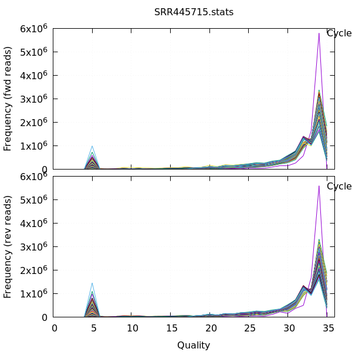

This graph describe that the majority of the cycles have a quality>30.

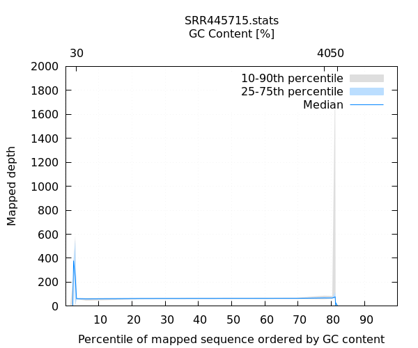

The GC depth looks good, otherwise preference would be seen towards sequencing GC.

## 2. Generating a pileup

Now we will generate a pileup from the BAM files. The command samtools mpileup prints the read bases that align to each position in the reference genome. Now try this:

```bash
samtools mpileup  -f /mnt/Timina/bioinfoII/drobles/variant_calling/data/S288C_ref.fa /mnt/Timina/bioinfoII/drobles/variant_calling/data/SRR445715.aligned.sorted.bam | less -S
# less -S -> te posiciona al principio.
```

Each line corresponds to a position on the genome. The columns are: chromosome, position, reference base, read depth, read bases (“.” or “,” indicates match on the forward or reverse strand; ACGTN and acgtn a mismatch on the forward and the reverse strand) and the final column is the base qualities encoded into characters. The symbol “^” marks the start of a read, “$” the end of a read, deleted bases are represented as “*“.

**Question 2:** What is the read depth at position chrI:29519? What is the reference base? Are there any non-reference bases?

```bash
samtools mpileup  -f /mnt/Timina/bioinfoII/drobles/variant_calling/data/S288C_ref.fa /mnt/Timina/bioinfoII/drobles/variant_calling/data/SRR445715.aligned.sorted.bam | less -S | grep 29519 -m 1
# -m->  significa "match" o "matches". Esta opción se utiliza para especificar el número máximo de ocurrencias de coincidencias que se deben imprimir.

# Otra forma:
#samtools mpileup -r chrI:29519-29519 -f /mnt/Timina/bioinfoII/drobles/variant_calling/data/S288C_ref.fa /mnt/Timina/bioinfoII/drobles/variant_calling/data/SRR445715.aligned.sorted.bam | less -S
# "-r" region; especifica la región.
```

read depth-> 56  
reference base-> A  
non-reference bases-> No

**Question 3:** What about at position chrI:29522? What is the reference base? Are there any non-reference bases?

```bash
samtools mpileup  -f /mnt/Timina/bioinfoII/drobles/variant_calling/data/S288C_ref.fa /mnt/Timina/bioinfoII/drobles/variant_calling/data/SRR445715.aligned.sorted.bam | less -S | grep 29522 -m 1
```

read depth-> 46  
reference base-> T  
non-reference bases-> Si, **A** tanto en foward como en revers.

## 3. Generating genotype likelihoods and variant calling

The bcftools mpileup command can be used to generate genotype likelihoods. Try running the following command:

```bash
# module load bcftools/1.10.2
module load bcftools
bcftools mpileup -f /mnt/Timina/bioinfoII/drobles/variant_calling/data/S288C_ref.fa /mnt/Timina/bioinfoII/drobles/variant_calling/data/SRR445715.aligned.sorted.bam | less -S
```

This is an intermediate output that contains genotype likelihoods (if you don’t remember what this is, go back to your notes on the Bayesian exercises we did!), as well as other raw information necessary to perform variant calling. However, we usually don’t see this information as it is streamed directly into the variant caller:

```bash
bcftools mpileup -f /mnt/Timina/bioinfoII/drobles/variant_calling/data/S288C_ref.fa /mnt/Timina/bioinfoII/drobles/variant_calling/data/SRR445715.aligned.sorted.bam | bcftools call -m --ploidy 1  | less -S
```

**Question 4:** Study the command. Why did we use these settings? If you were performing variant calling in human data, what settings would you use?

“-m” -> include variants that have a QUAL record greater than zero (filters low quality calls) and “–ploidy 1”-> sets the ploidy of the genotype with 1, means that each sample is assumed to have only one allele at each position (haploid). If we were to perform a variant calling in human data, we need to especify 2 (diploid).

**Question 5:** What option should we add to only print variant sites?

-v -> llama variantes solo en las posiciones en las que hay una variante presente en al menos una muestra.

The INFO and FORMAT fields of each entry tells us something about the data at the position in the genome. It consists of a set of key-value pairs with the tags being explained in the header of the VCF file (see the ##INFO and ##FORMAT lines in the header). Let mpileup output more information. For example we can ask it to add the FORMAT/AD tag which informs about the number of high-quality reads that support alleles listed in REF and ALT columns. The list of all available tags can be printed with “bcftools mpileup -a?”. Now let’s run the variant calling again, this time adding the -a AD option. We will also add the -Ou option to mpileup so that it streams a binary uncompressed BCF into call. This is to avoid the unnecessary CPU overhead of formatting the internal binary format into plain text VCF only to be immediately formatted back to the internal binary format again (this will take a little while, so remember to not run this command in the head node!):

```bash
# 1
bcftools mpileup -a AD -f /mnt/Timina/bioinfoII/drobles/variant_calling/data/S288C_ref.fa /mnt/Timina/bioinfoII/drobles/variant_calling/data/SRR445715.aligned.sorted.bam -Ou | bcftools call -mv --ploidy 1 -o SRR445715.vcf
# 2
bcftools mpileup -a AD -f /mnt/Timina/bioinfoII/drobles/variant_calling/data/S288C_ref.fa /mnt/Timina/bioinfoII/drobles/variant_calling/data/SRR445716.aligned.sorted.bam -Ou | bcftools call -mv --ploidy 1 -o SRR445716.vcf
# 3
bcftools mpileup -a AD -f /mnt/Timina/bioinfoII/drobles/variant_calling/data/S288C_ref.fa /mnt/Timina/bioinfoII/drobles/variant_calling/data/SRR445717.aligned.sorted.bam -Ou | bcftools call -mv --ploidy 1 -o SRR445717.vcf
```

Note: run this command for all three BAM files, this will be important for the next exercises.

Now examine the VCF file output of file *SRR445717.vcf* using the UNIX command *less*:

```bash
less -S SRR445717.vcf
```

**Question 6:** What is the reference and variant base at position chrIV:122724?

```bash
less -S SRR445717.vcf | grep chrIV | grep 122724
#chrIV  122724  .   G   A   225 .   DP=58;VDB=0.0205157;SGB=-0.693147;MQSB=1;MQ0F=0;AC=1;AN=1;DP4=0,0,27,26;MQ=60   GT:PL:AD    1:255,0:0,53
```

Reference -> G  
Alternative -> A

**Question 7:** What is the total read depth at position chrIV:122724?

Read depth -> 58

**Question 8:** What is the number of high-quality forward reads supporting the variant call at position chrIV:122724? How many reads support the reference allele?

High-quality forward reads supporting the variant call -> 27  
Reads support the reference allele -> 0

**Question 9:** What sort of event is happening at position chrI:29007?

```bash
less -S SRR445717.vcf | grep chrI | grep 29007 -m 1
#chrI   29007   .   T   TG  122 .   INDEL;IDV=23;IMF=0.958333;DP=24;VDB=0.0158681;SGB=-0.636426;MQSB=0.882497;MQ0F=0;AC=1;AN=1;DP4=4,13,2,5;MQ=35   GT:PL:AD    1:149,0:17,7
```

Is happening an INDEL at position chrI:29007.

## 4. Variant filtering

In the series of commands we will learn how to filter and extract information from VCFs. Most of the bcftools commands accept the -i, –include and -e, –exclude options which will come handy when filtering using fixed thresholds (you can look at the bcftools documentation here: http://www.htslib.org/doc/bcftools.html). We will estimate the quality of the callset by calculating the transition/transversion ratio.

In order to verify that the filtering expression has the desired effect, it is useful to first run a few small tests. Let’s start with printing a simple list of positions from the VCF using the bcftools query command (manual) and pipe through the head command to trim the output after a few lines:

```bash
bcftools query -f'POS = %POS\n' SRR445715.vcf | head
```

The formatting expression “POS = %POS” was expanded for each line in the VCF and consisted of the string “POS =”, which was printed on the output unchanged, the string with a special meaning “%POS”, which was replaced by the POS column for each line, and the new line character “”, which put the new line character after each VCF record. (If it were not present, the positions from the entire VCF would be printed on a single line.)

Now add REF and ALT allele to the output, separated by a comma

```bash
bcftools query -f'POS = %POS, REF = %REF, ALT = %ALT\n' SRR445715.vcf | head
```

In the next step add also the quality, genotype and sequencing depth to the output. For the depth, check the AD annotation, which gives the number of reads observed for each reference and alternate alleles. For example, if there were 3 reads with the reference allele and 5 reads with the alternate allele, the AD field would be AD=3,5. Note that the FORMAT fields must be enclosed within square brackets “[]” to iterate over all samples in the VCF.

To illustrate this, first let’s make a combined VCF:

```bash
# module load htslib/1.9
module load htslib
bgzip SRR445715.vcf
bgzip SRR445716.vcf
bgzip SRR445717.vcf
bcftools index SRR445715.vcf.gz
bcftools index SRR445716.vcf.gz
bcftools index SRR445717.vcf.gz
bcftools merge -0 -o combined.vcf SRR445715.vcf.gz SRR445716.vcf.gz SRR445717.vcf.gz
# "merge" -> Merge multiple VCF/BCF files from non-overlapping sample sets to create one multi-sample file. For example, when merging file A.vcf.gz containing samples S1, S2 and S3 and file B.vcf.gz containing samples S3 and S4, the output file will contain five samples named S1, S2, S3, 2:S3 and S4.
# "-0"=--missing-to-ref -> assume genotypes at missing sites are 0/0.
# All this files are in your carpet.
```

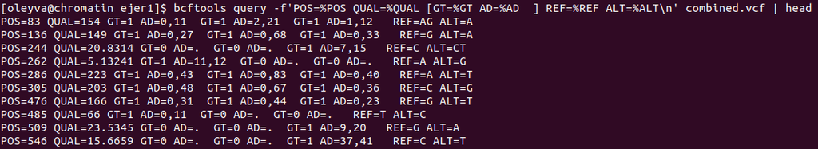

```bash
bcftools query -f'POS=%POS QUAL=%QUAL [GT=%GT AD=%AD  ] REF=%REF ALT=%ALT\n' combined.vcf | head
# Allelic depth.
```

Now filter rows with quality smaller than 30 and exclude indels. Check the record at positions 83, 244, 262, 509, 546, are they still present in the output?

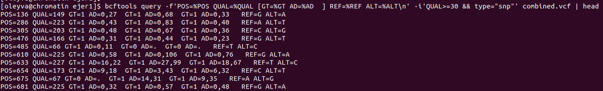

```bash
bcftools query -f'POS=%POS QUAL=%QUAL [GT=%GT AD=%AD  ] REF=%REF ALT=%ALT\n' -i'QUAL>=30 && type="snp"' combined.vcf | head
```

NO, they aren’t present with the new filter.

**Question 10:** Can you print rows with QUAL bigger than 30 and with at least 50 alternate reads? For this we will need to query the second value of the AD field. Note that the indexes are zero-based; the first AD value is represented as “AD[0]”, therefore the second value must be queried as “AD[1]>=50”. However, you will also need to indicate which sample to look at, to look at any sample you can use the asterisk (e.g. the instruction would look like “AD[*:1]>=50”) Hint: If you get stuck, look at the examples that Petr Danecek (pd3) explained here: https://github.com/samtools/bcftools/issues/757

Yes, like this:

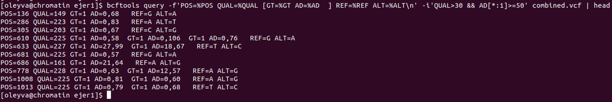

```bash
bcftools query -f'POS=%POS QUAL=%QUAL [GT=%GT AD=%AD  ] REF=%REF ALT=%ALT\n' -i'QUAL>30 && AD[*:1]>=50' combined.vcf | head
```

Finally, use the following command to obtain the ts/tv(transition/tranversion) of an unfiltered callset.

```bash
bcftools stats SRR445715.vcf.gz | grep TSTV | cut -f5
```

Results:

```bash
TSTV, transitions/transversions:
[5]ts/tv
ts/tv of removed sites: 2.94
```

It indicates the relationship between the number of transitions and transversions in the VCF file, it means that for every 2.94 transitions there is 1 transversion.

**Question 11:** How does the ts/tv change if you apply the filters above? Use the bcftools stats command with the -i option to include calls with QUAL at least 30 and the number of alternate reads at least 50.

```bash
bcftools stats -i'QUAL>=30 && AD[*:1]>=50' SRR445715.vcf.gz | grep TSTV | cut -f5 | head
```

Results:

```bash
TSTV, transitions/transversions:
[5]ts/tv
ts/tv of removed sites: 3.31
```

In this case it means that for every 3.31 transitions there is 1 transversion.

**Question 12:** What is the ts/tv of removed sites?

```bash
bcftools stats -e'QUAL>=30 && AD[*:1]>=50' SRR445715.vcf.gz | grep TSTV | cut -f5 | head
```

Results

```bash
TSTV, transitions/transversions:
[5]ts/tv
ts/tv of removed sites: 2.46
```

ts/tv of removed sites -> 2.46.

Another useful command is filter which allows you to annotate the VCF file with soft filters based on the given expression, rather than removing the sites completely. Can you apply the above filters to produce a final callset and apply the -g and -G options to soft filter variants around indels?

```bash
bcftools filter -m+ -i'QUAL>=30 && AD[*:1]>=50' -g8 -G10 combined.vcf -o combined.flt.vcf
# -sLowQual -> etiqueta variantes que no pasan el filtro con "LowQual" (campo filtro).  Si le quitamos este termino se quedan en el archivo solo las variantes que pasan el filtro.
# -m+ ->  indica las variantes que pasen el filtro con PASS (campo "FILTER").
# -g8 -> elimina variantes con mala calidad.
# -G10 -> filtra clusters de inserciones y deleciones que están separados por un número determinado de pares de bases y permite que solo una variante pase.
```

**Question 13:** Can you see why position chrI:1101 passed these filters? And why did position chrI:1107 fail the filtering step?

## 5. Multi-sample variant calling

Many experiments involve sequencing multiple samples to compare the genetic variation between the samples. Therefore, we need to have a genotype for each sample at all variant sites. Typically this is achieved by carrying out multi-sample variant calling where all of the sequencing data is given to the variant caller simultaneously.

**Question 14:** There are three BAM files in the original directory /mnt/Timina/bioinfoII/drobles/variant_calling/data/. Can you modify the command from section 3 to use all three BAM files and only write out variant sites in chromosome I? Write the output to a compressed BCF file called multi.bcf and index the file afterwards.

```bash
bcftools mpileup -r chrI -a AD -f /mnt/Timina/bioinfoII/drobles/variant_calling/data/S288C_ref.fa /mnt/Timina/bioinfoII/drobles/variant_calling/data/SRR44571*.aligned.sorted.bam -Ou | bcftools call -mv --ploidy 1 -o multi.vcf
# "-r chrI"->specifies that the pileup should only be generated for chromosome I.
# "-a AD"->specifies that the allelic depth (AD) should be included in the output.
# "-v"-> imprime solamente las variantes.

#Number of rows:
wc -l multi.vcf

# To index:
module load htslib
bgzip multi.vcf
bcftools index multi.vcf.gz
```

Indexed file: `multi.vcf.gz.csi`

955 variant sites in the chromosome I.

**Question 15:** Can you apply the same filters as before? How many sites pass the filters? Write the output to a BCF file called multi.filt.bcf and index the file.

Yes, like this;

```bash
# bcftools query -f'POS=%POS QUAL=%QUAL [GT=%GT AD=%AD  ] REF=%REF ALT=%ALT\n' multi.bcf.gz | head
bcftools filter -m+ -i'QUAL>=30 && AD[*:1]>=50' -g8 -G10 multi.vcf.gz -o multi.filt.vcf

# Number of rows:
wc -l    multi.filt.vcf

# To index:
module load htslib
bgzip multi.filt.vcf
bcftools index multi.filt.vcf.gz
```

Indexed file: `multi.filt.vcf.gz.csi`

525 are the sites that pass the filters.

**Question 16:** What is the ts/tv of the raw calls and of the filtered set?

```bash
# Raw
bcftools stats multi.vcf.gz | grep TSTV | cut -f5
# Filtered
bcftools stats multi.filt.vcf.gz | grep TSTV | cut -f5
```

Results:

```bash
# Raw
TSTV, transitions/transversions:
[5]ts/tv
2.58
# Filtered
TSTV, transitions/transversions:
[5]ts/tv
3.11
```

Like in the before questions, if we filtered the data, we obtain that the relation between the number of transitions and transversions increase, it means that are 2.58(raw) and 3.11(filtered) transitions per 1 transversion.

# Día 2

## VEP and more bcftools analyses

Now that we have done some of the basics, we will now delve into the original problem and answer some questions regarding the original sequencing files.

### 1. Thinking about our experiment

First, what are the differences between the parent strain of the study (CEN.PK113-7D) and the reference strain S288C? The (unfiltered) differences of course are the variant calls present in SRR445715.vcf.gz, as we used the S288C genome as a reference. But, how do we find the differences between the evolved strain IMW004 and its parent CEN.PK113-7D? For this, we can also use bcftools:

```bash
bcftools isec -C SRR445716.vcf.gz SRR445715.vcf.gz > present_in_IMW004_absent_in_CEN.PK113-7D.txt
```

From this analysis, we can see there are a number of variants present in IMW004 that were not present in its parent strain.

Okay, so now the real question. What are the variants, and the gene, underlying the newly acquired ability of IMW004 and IMW005 to grow on lactate? Since these two strains have evolved completely separately, the chance of them sharing an exactly identical variant that is not present in their parent strain is extremely low. However, it is certainly possible that different variants in the two strains will affect the same genomic feature (e.g., the same gene), which could then be taken as evidence that this gene may be of importance for the observed biological effect (growth on lactate in this case). Hint 2: Study the bcftools isec and bcftools merge commands.

**Question 17:** Can you think of a way to obtain a list of candidates that may underlie the ability of these strains to grow on lactate? Hint: You can assume that variants shared by both IMW004 and IMW005 are likely to have arisen before the start of the experiment (i.e., from the unsequenced initial jen1 delta strain), and therefore are not biologically interesting. How many variants (unfiltered) are in IMW004 that are not shared by any other strain?

I think that we have to compare the two lab-evolved substrains with the parent strain to obtain the list of candidates that may underlie the ability to grow on lactate.

To know how many variants are in IMW004 that are not shared by any other strain, we have to do:

```bash
# Se agrega a la original porque habra variantes que se encuentren en las cepas pero no en la original.
# CEN.PK113-7D parent strain -> SRR445715
# Lab-evolved substrain IMW004 -> SRR445716
# Lab-evolved substrain IMW005 -> SRR445717
bcftools isec -C SRR445716.vcf.gz SRR445717.vcf.gz SRR445715.vcf.gz > present_in_IMW004_absent_in_others.txt
# "isec" -> Creates intersections, unions and complements of VCF files. Depending
  #on the options, the program can output records from one (or more) files which
  #have (or do not have) corresponding records with the same position in the
  #other files.
# "-C" -> output positions present only in the first file but missing in the
  #others.

# Number of rows:
wc -l present_in_IMW004_absent_in_others.txt
```

We obtained 209 variants.

Now, can you apply filters to remove those sites that are not well-covered? let’s set it at DP>30 and QUAL>50.

```bash
# Filter:
bcftools isec -i'QUAL>50 && DP>30' -i'-' -i'-' -C SRR445716.vcf.gz SRR445717.vcf.gz SRR445715.vcf.gz > present_in_IMW004_absent_in_others_filter.txt

# Pass to vcf:
bcftools view -O v -R present_in_IMW004_absent_in_others_filter.txt SRR445716.vcf.gz -o SRR445716_unique.flt.vcf
```

**Question 18:** How many variants remain in IMW004 after filtering?

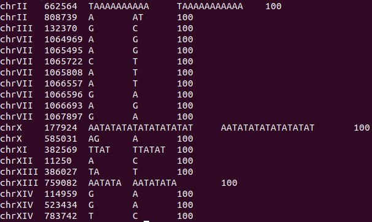

```bash
# Number of rows:
wc -l present_in_IMW004_absent_in_others_filter.txt

# VCF:
bcftools view -H SRR445716_unique.flt.vcf | wc -l
```

We obtained 20 variants in the “.txt”.

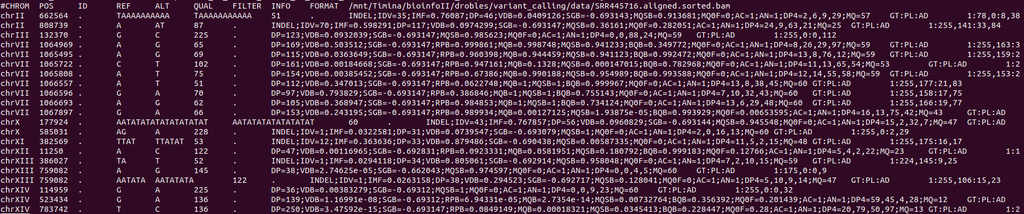

We obtained 21 variants in the “.vcf”, there is one more than in the “.txt”, because there are three repetitions of the “chrXIII”.

Now, do the same you did for IMW004 but now for IMW005.

Raw data;

```bash
bcftools isec -C SRR445717.vcf.gz SRR445716.vcf.gz SRR445715.vcf.gz > present_in_IMW005_absent_in_others.txt

# Number of rows:
wc -l present_in_IMW005_absent_in_others.txt
```

We obtained 244 variants.

Filtered data;

```bash
bcftools isec -i'QUAL>50 && DP>30' -i'-' -i'-' -C SRR445717.vcf.gz SRR445716.vcf.gz SRR445715.vcf.gz > present_in_IMW005_absent_in_others_filter.txt

# Pass to vcf:
bcftools view -O v -R present_in_IMW005_absent_in_others_filter.txt SRR445717.vcf.gz -o SRR445717_unique.flt.vcf
```

**Question 19:** How many variants remain in IMW005 after filtering?

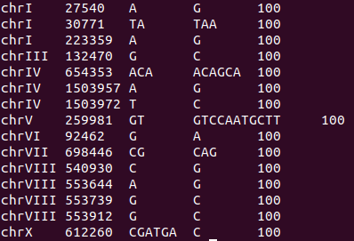

```bash
# Number of rows:
wc -l present_in_IMW005_absent_in_others_filter.txt

# VCF:
bcftools view -H SRR445717_unique.flt.vcf | wc -l
```

We obtained 15 variants in the “.txt”.

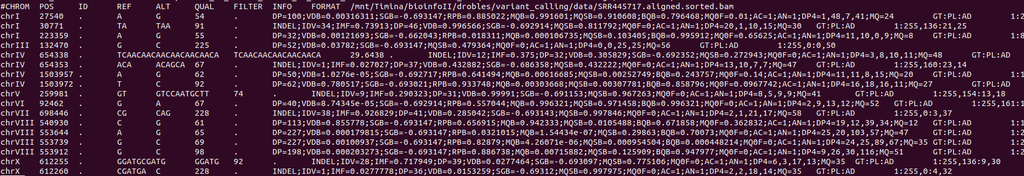

We obtained 17 variants in the “.vcf”, there are two chromosomes more than in the “.txt”, because there are four and two repetitions of the “chrIV” and “chrx” respectively.

### 2. Running Ensembl Variant Efect Predictor(VEP) and obtaining the information about biological consequences

Now we will run Ensembl VEP on our files and see what gene consequences our mutations have. Previous to this, I installed the yeast cache (a local database so we don’t have to connect to the database in the UK) in my home directory, so we can use these. To run VEP on your files, try:

```bash
# IMW004 -> SRR445716
# qlogin
module load vep/r99.2
# My archive unzipped: VCuniquetoSRR445716.filter.vcf; list of variants
  #that are unique to the SRR445716.
vep --cache --dir_cache /home/drobles/.vep/ -i SRR445716_unique.flt.vcf -o SRR445716_unique.flt.vep.vcf --vcf --species "saccharomyces_cerevisiae"
```

**Question 20:** What do all the options that we added to the command mean? Hint: Look at the full options in http://www.ensembl.org/info/docs/tools/vep/script/vep_options.html.

```bash
# "-i" -> indicates the name of the input file.
# "--cache" -> indicates that the VEP reference cache should be used.
# "--dir_cache" -> specifies the exact location of the reference cache directory
  #on the local system.
# "--vcf" -> indicates the format type of the output.
# "--species" -> indicates the species of the organism in which the variants
  #have been detected.
```

**Question 21:** Look at the output VCF. What happened to the original VCF? Did VEP add an annotation? Which one?

Original output VCF:

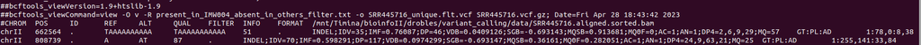

VEP output VCF:

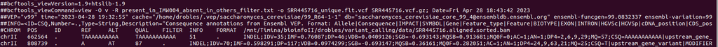

Yes, Variant Effect Predictor (vep) add the next annotations to the original “vcf” the input archive, plus information about the variants, like; location in the genome, the potential functional effects of the variant, impact on the proteins encoded by the genes, the frequency in reference populations.

### Making sense of our results

```bash
# IMW005 -> SRR445717
# qlogin
module load vep/r99.2
vep --cache --dir_cache /home/drobles/.vep/ -i SRR445717_unique.flt.vcf -o SRR445717_unique.flt.vep.vcf --vcf --species "saccharomyces_cerevisiae"
```

Run VEP on both IMW004 and IMW005 filtered VCF files. Study the output very well. Now create a program in your favorite language that outputs:

```
Genes are mutated in any or both of the files
What mutation is present in what strain
```

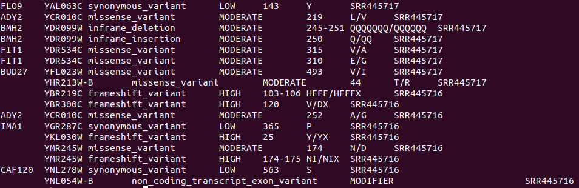

```bash
# coding: utf-8
root = "/mnt/Timina/bioinfoII/oleyva/daniela/ejer1/"
files = {
    'SRR445716': root + "/SRR445716_unique.flt.vep.vcf",
    'SRR445717': root + "/SRR445717_unique.flt.vep.vcf"
} # Se define la ubicación de los archivos de entrada y se crea un hash que asocia una muestra con el archivo VCF correspondiente.

up_and_down = {'upstream_gene_variant', 'downstream_gene_variant'}
i =0
for file in files:
    with open(files[file], 'r') as f:
        for line in f:
            if line.startswith('#'):
                continue
            if 'CSQ=' in line:
                csqs = line.split('CSQ=')[1]
                csqs = csqs.split('GT:PL:AD')[0]
                csqs = csqs.split(',')
                for csq in csqs:
                    csq = csq.split('|')
                    if csq[1] not in up_and_down:
                        print(csq[3] + "\t" + csq[4] + "\t" + csq[1] + "\t" + csq[2] + "\t" + csq[14] + "\t" + csq[15] +  "\t" + file)
```

Did you find the original mutations found by the authors in the ADY2 gene?

**Question 22:** Filter the consequences to only keep those that are either missense, stop gained, frameshift, splice acceptor or splice donor. These are typically the mutations that are predicted to directly affect protein function. How many genes are mutated with any of these consequences in both strains?

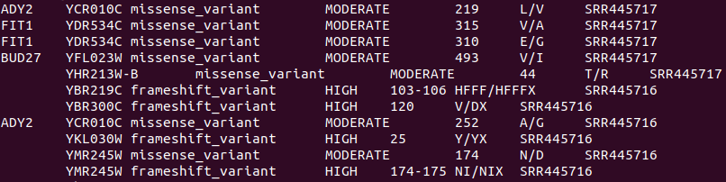

```bash
#!/usr/bin/python
#
root = "/mnt/Timina/bioinfoII/oleyva/daniela/ejer1/"
files = {
    'SRR445717': root + "/SRR445717_unique.flt.vep.vcf",
    'SRR445716': root + "/SRR445716_unique.flt.vep.vcf"
}

csq_to_keep = {'frameshift_variant', 'missense_variant'}
i =0
for file in files:
    with open(files[file], 'r') as f:
        for line in f:
            if line.startswith('#'):
                continue
            if 'CSQ=' in line:
                csqs = line.split('CSQ=')[1]
                csqs = csqs.split('GT:PL:AD')[0]
                csqs = csqs.split(',')
                for csq in csqs:
                    csq = csq.split('|')
                    if csq[1] in csq_to_keep:

                        print(csq[3] + "\t" + csq[4] + "\t" + csq[1] + "\t" + csq[2] + "\t" + csq[14] + "\t" + csq[15] +  "\t" + file)
```

Hint: If you’ve tried and haven’t managed to finish this exercise, you can see the program (in Perl!) that I wrote for this in: /mnt/Timina/bioinfoII/drobles/variant_calling/data/other_files/scripts/get_recurrently_mutated_genes.pl.

```bash
# qlogin
# To run the code: ./perlclase.pl

#!/usr/bin/perl
#
use strict;
use warnings;

my $root = "/mnt/Timina/bioinfoII/oleyva/daniela/ejer1";
my %files = (
    'SRR445716' => "$root/SRR445716_unique.flt.vep.vcf",
    'SRR445717' => "$root/SRR445717_unique.flt.vep.vcf " );

my %mutations;
my @csqs_to_keep = ( 'missense', 'frameshift', 'stop', 'splice' );

#obtain recurrently mutated genes
foreach my $file ( keys %files ){
    open( FILE, $files{ $file } ) or die;
    while( <FILE> ){
        if( $_ =~ /^\#/ ){ next; }
        if( $_ =~ /CSQ\=([^\t]+)/ ){
            my @csqs = split( /\,/, $1 );
            foreach my $csq ( @csqs ){
                my @fields = split( /\|/, $csq );
                my ( $gene, $tr, $csq, $aa ) = ( 'undefined', 'undefined', 'undefined', 'undefined' );

                #check if we are interested in the consequence, if not, discard
                if( !grep{ $fields[1] =~ /$_/ } @csqs_to_keep ){ next; }

                if( defined( $fields[4] ) ){ #this is the gene name
                    $gene = $fields[4];
                    if( $fields[3] ne '' ){
                        $gene .= " ($fields[3])";
                    }
                }
                if( defined( $fields[6] ) ){ #this is the transcript
                    $tr = $fields[6];
                }
                if( defined( $fields[1] ) ){ #this is the consequence
                    $csq = $fields[1];
                }
                if( defined( $fields[14] ) and defined( $fields[15] ) ){ #this is aa info
                    $aa = $fields[14] . ' ' . $fields[15];
                }
                #save in results hash: gene, transcript, sample, consequence and aa
                $mutations{ $gene }{ $tr }{ $file } = $csq . ", " . $aa;
            }
        }
    }
    close( FILE );
}

#print results
foreach my $gene ( sort keys %mutations ){
    foreach my $tr ( sort keys %{ $mutations{ $gene } } ){
        foreach my $sample ( sort keys %{ $mutations{ $gene }{ $tr } } ){
            print ( $gene . "\t" . $tr . "\t" . $sample . "\t" . $mutations{ $gene }{ $tr }{ $sample } . "\n" );
        }
    }
}
```

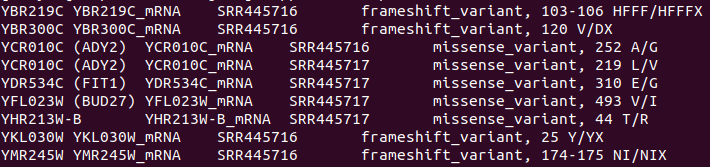

We obtain almost the same results except for two mutations, one in the gene YDR534C (FIT1) and other in the YMR245W.

# Día 3

## Using the Ensembl API to obtain more information about our candidates

Now write a script that retrieves the function for all the genes in your candidate list (Hint: You can use the gene description to do this.)

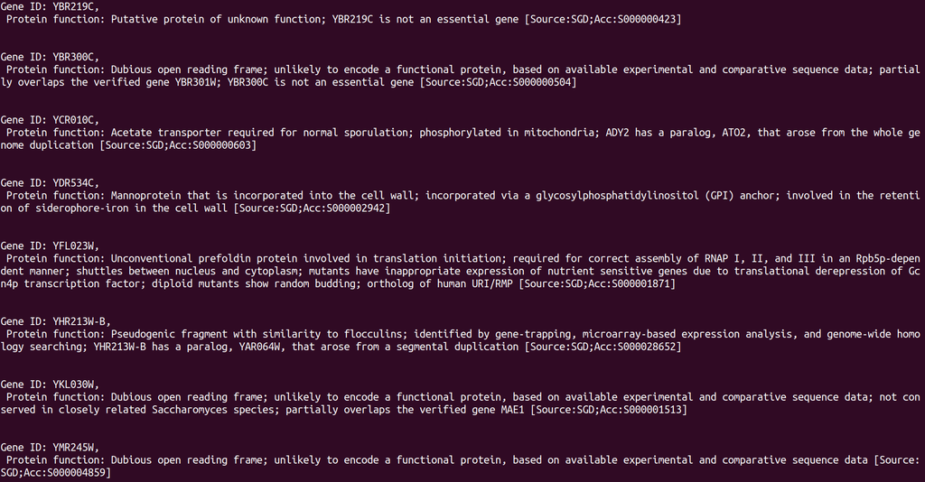

```bash
# -*- coding: utf-8 -*-
import requests
  # "-*- coding: utf-8 -*-":  indicate that the Python file is encoded in UTF-8,
    #so the Python interpreter knows how to decode the characters.
  # "requests": used to make HTTP requests to the Ensembl REST API and retrieve
    #information about genes, transcripts, proteins, and other biological
    #entities.
  # HTTP: is a protocol based on a request-response model, where the client makes
    #a request and the server responds with the requested information.

# Function to obtain information of a certain gene from its ID in Ensembl.
def get_gene_info(ensembl_id):
    server = "https://rest.ensembl.org"
    ext = "/lookup/id/" + ensembl_id + "?expand=1"
    headers = {"Content-Type": "application/json"}
    r = requests.get(server+ext, headers=headers)
    if not r.ok:
        r.raise_for_status()
        sys.exit()
    decoded = r.json()
    return decoded
  # "def": define the function "get_gene_info" that takes "ensembl_id" as
    #parameter.
  # "ext": text string that specify the URL extension that will be used to make
    #an HTTP request to the Ensembl API. Constructed by concatenating the string
    #"/lookup/id/" with the "ensembl_id" and adding the parameter "?expand=1"
    # indicating the desired to add additional data related to the gene.
  # "headers = {"Content-Type": "application/json"}": Sets the 'headers' variable
    #to a dictionary containing the 'Content-Type' header, which specifies that
    #the data being sent and received is in 'JSON' format.
  # "r = requests.get(server+ext, headers=headers)": send a request using the
    #server, ext, and headers variables, by a 'GET request' to the Ensembl
    #REST API.
  # "if not r.ok": if "r" has not a valid HTTP status code using the "ok",
    #"r.raise_for_status()" raises an HTTPError to indicate something wrong with
    #the request and "sys.exit()" comes out the program.
  # "decoded = r.json()": If "r" is valid, "r.json()" decodes the JSON response
    #into a Python object, and "return decoded" returns this decoded object.

# "Function to obtain the ID of the protein that encodes the aforementioned gene in Ensembl."
def get_protein_id(ensembl_id):
    gene_info = get_gene_info(ensembl_id)
    transcript_id = gene_info['Transcript'][0]['id']
    server = "https://rest.ensembl.org"
    ext = "/lookup/id/" + transcript_id + "?expand=1"
    headers = {"Content-Type": "application/json"}
    r = requests.get(server+ext, headers=headers)
    if not r.ok:
        r.raise_for_status()
        sys.exit()
    decoded = r.json()
    protein_id = decoded['Translation']['id']
    return protein_id

  # "transcript_id" : save the information from the "gene_info" to access the
    # list of Transcripts associated with that gene. The first element is
    #extracted using "[0]" syntax, and the "id" of that element is accessed
    #using the "['id']" syntax.
  # "protein_id": save the protein "ID" corresponding to the transcript using the
    #decoded['Translation']['id'] syntax. This is done assuming that the protein
    #"ID" is stored in the "id" field under the "Translation" key.
  # "return protein_id": returns the decoded "protein_id" object.

# Function to obtain the information of a protein from its ID in Ensembl.
función para obtener la información de una proteína a partir de su ID en Ensembl
def get_protein_info(protein_id):
    server = "https://rest.ensembl.org"
    ext = "/lookup/id/" + protein_id + "?expand=1"
    headers = {"Content-Type": "application/json"}
    r = requests.get(server+ext, headers=headers)
    if not r.ok:
        r.raise_for_status()
        sys.exit()
    decoded = r.json()
    return decoded
  # This part of the code is the same as the information of the gene, but for
    #the protein information.

# List of the candidate genes obtained before.
gene_ids = ["YBR219C", "YBR300C", "YCR010C", "YDR534C", "YFL023W", "YHR213W-B", "YKL030W", "YMR245W"]

# Obtain information on the function of the protein encoded by each gene and display it.
for gene_id in gene_ids:
    protein_id = get_protein_id(gene_id)
    protein_info = get_protein_info(protein_id)
    print("Gene ID: {},\n Protein function: {}".format(gene_id, protein_info['description']))
    print('\n')
  # This code uses a loop to iterate over a list of gene IDs. For each gene ID,
    #it calls two functions: get_protein_id() and get_protein_info(). Then print
    #the information of each one.
```